# Handling_Missing_Values

Yu Ling Hsu

Load data file melb_data.csv

```r
Melbourne_data <- read.csv("melb_data.csv")
head(Melbourne_data)
```

```
##       Suburb          Address Rooms Type   Price Method SellerG      Date
## 1 Abbotsford     85 Turner St     2    h 1480000      S  Biggin 3/12/2016
## 2 Abbotsford  25 Bloomburg St     2    h 1035000      S  Biggin 4/02/2016
## 3 Abbotsford     5 Charles St     3    h 1465000     SP  Biggin 4/03/2017
## 4 Abbotsford 40 Federation La     3    h  850000     PI  Biggin 4/03/2017
## 5 Abbotsford      55a Park St     4    h 1600000     VB  Nelson 4/06/2016
## 6 Abbotsford   129 Charles St     2    h  941000      S  Jellis 7/05/2016
##   Distance Postcode Bedroom2 Bathroom Car Landsize BuildingArea YearBuilt
## 1      2.5     3067        2        1   1      202           NA        NA
## 2      2.5     3067        2        1   0      156           79      1900
## 3      2.5     3067        3        2   0      134          150      1900
## 4      2.5     3067        3        2   1       94           NA        NA
## 5      2.5     3067        3        1   2      120          142      2014
## 6      2.5     3067        2        1   0      181           NA        NA
##   CouncilArea Lattitude Longtitude            Regionname Propertycount
## 1       Yarra  -37.7996   144.9984 Northern Metropolitan          4019
## 2       Yarra  -37.8079   144.9934 Northern Metropolitan          4019
## 3       Yarra  -37.8093   144.9944 Northern Metropolitan          4019
## 4       Yarra  -37.7969   144.9969 Northern Metropolitan          4019
## 5       Yarra  -37.8072   144.9941 Northern Metropolitan          4019
## 6       Yarra  -37.8041   144.9953 Northern Metropolitan          4019
```

Visualizing Missing Values:

```r
library(VIM)
library(mice)
names(Melbourne_data)
```

```
##  [1] "Suburb"        "Address"       "Rooms"         "Type"
##  [5] "Price"         "Method"        "SellerG"       "Date"
##  [9] "Distance"      "Postcode"      "Bedroom2"      "Bathroom"
## [13] "Car"           "Landsize"      "BuildingArea"  "YearBuilt"
## [17] "CouncilArea"   "Lattitude"     "Longtitude"    "Regionname"
## [21] "Propertycount"
```

```r
# Renaming variables to smallers size names to make them fit in the figure
names(Melbourne_data)[15] <- "BldgArea"
names(Melbourne_data)[17] <- "CunclArea"
names(Melbourne_data)[20] <- "RgnNam"
names(Melbourne_data)[21] <- "PrpCnt"
```

Q.1 Create a new dataset (give it a new name “Melb_All_Missing_dropped”) by removing all the missing values in Melbourne_data. Hint: Use na.omit()

```r
Melb_All_Missing_dropped <- na.omit(Melbourne_data)
Melb_All_Missing_dropped
```

[output not shown]

[output cut: 19034 more lines]

Q.2 Calculate the percentage of datapoints dropped. Hint: Use nrow() to calculate the number of rows (datapoints) in a dataset.

```r
ndrop <- nrow(Melb_All_Missing_dropped) #put into a variable
norigin <- nrow(Melbourne_data) #put into a variable
percentage = ((norigin - ndrop) / norigin) * 100 #*100 cause want to become a precentage
percentage
```

```
## [1] 49.70545
```

```r
#49 is more than the half, is better to use some function to keep the data
```

We see that about half (49.7%) of the data has been deleted. It can be a problem if you don’t have a lot of data points.

Now let’s delete the variables that have most of the missing values. Find which variables have large number of missing values.

Q.3 Write code for visulaizing missing values using md.pattern(), aggr() and matrixplot() functions. Identify the variables that have most missing values.

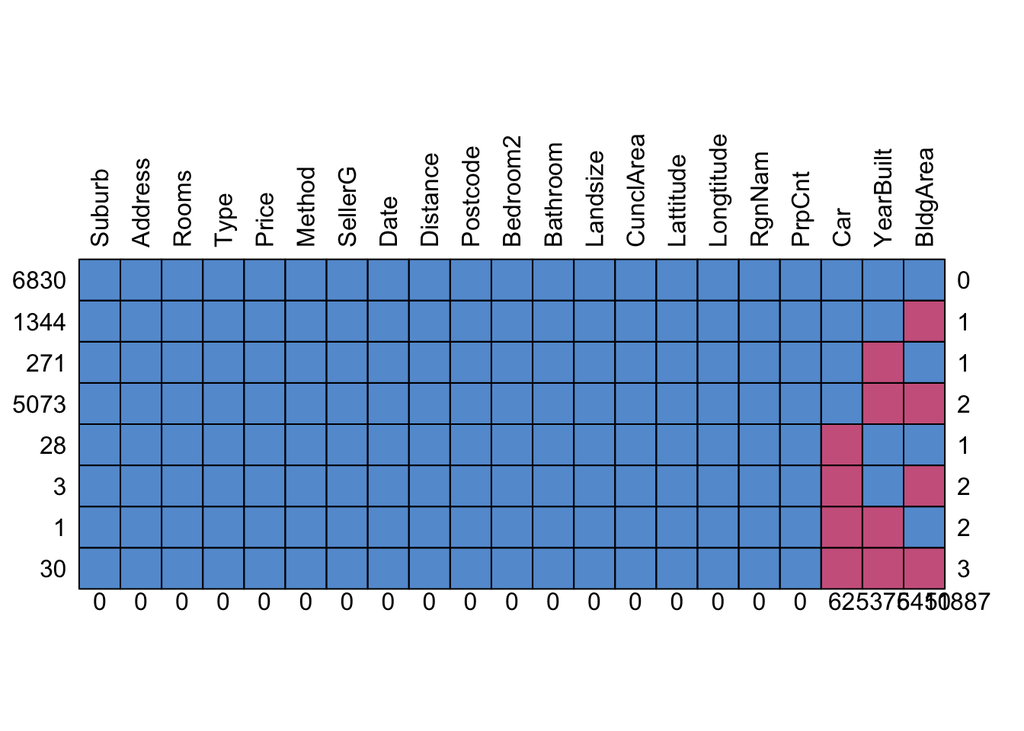

```
##      Suburb Address Rooms Type Price Method SellerG Date Distance Postcode
## 6830      1       1     1    1     1      1       1    1        1        1
## 1344      1       1     1    1     1      1       1    1        1        1
## 271       1       1     1    1     1      1       1    1        1        1
## 5073      1       1     1    1     1      1       1    1        1        1
## 28        1       1     1    1     1      1       1    1        1        1
## 3         1       1     1    1     1      1       1    1        1        1
## 1         1       1     1    1     1      1       1    1        1        1
## 30        1       1     1    1     1      1       1    1        1        1
##           0       0     0    0     0      0       0    0        0        0
##      Bedroom2 Bathroom Landsize CunclArea Lattitude Longtitude RgnNam PrpCnt
## 6830        1        1        1         1         1          1      1      1
## 1344        1        1        1         1         1          1      1      1
## 271         1        1        1         1         1          1      1      1
## 5073        1        1        1         1         1          1      1      1
## 28          1        1        1         1         1          1      1      1
## 3           1        1        1         1         1          1      1      1
## 1           1        1        1         1         1          1      1      1
## 30          1        1        1         1         1          1      1      1
##             0        0        0         0         0          0      0      0
##      Car YearBuilt BldgArea
## 6830   1         1        1     0
## 1344   1         1        0     1
## 271    1         0        1     1
## 5073   1         0        0     2
## 28     0         1        1     1
## 3      0         1        0     2
## 1      0         0        1     2
## 30     0         0        0     3
##       62      5375     6450 11887
```

```r
md.pattern(Melbourne_data, rotate.names = TRUE) #rotate.name to see the name clearly
```

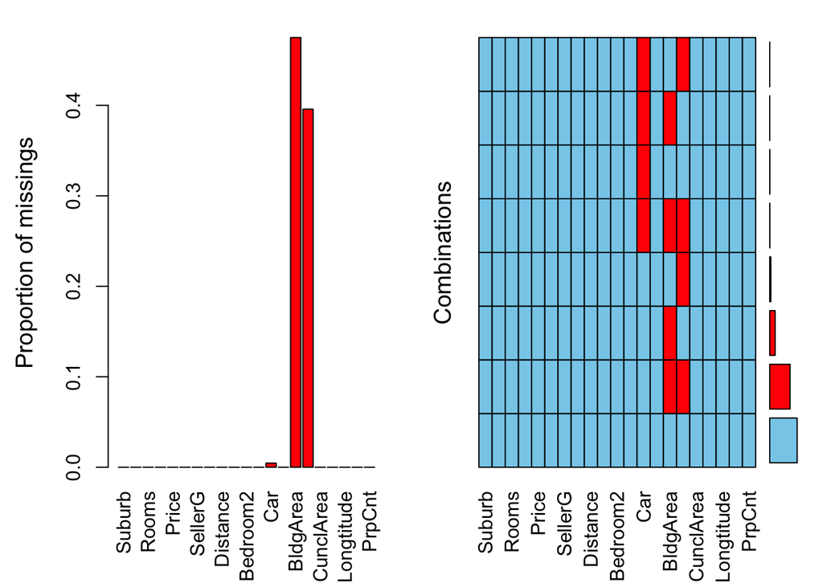

```r
aggr(x = Melbourne_data)
```

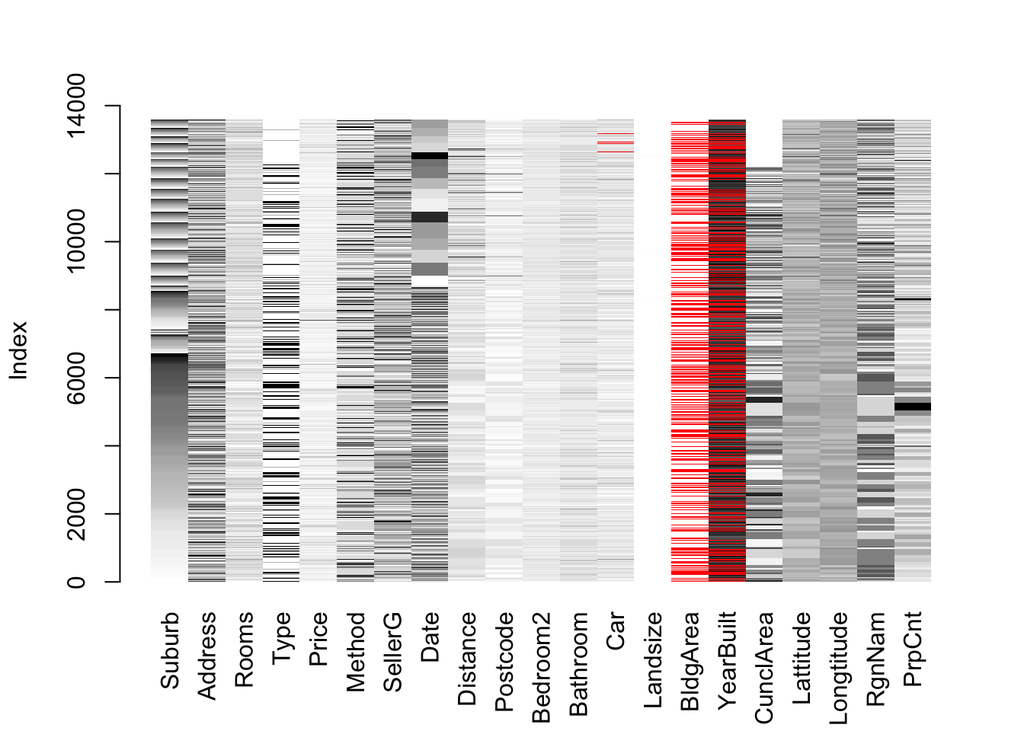

```
##
## Click in a column to sort by the corresponding variable.
## To regain use of the VIM GUI and the R console, click outside the plot region.
```

```r
matrixplot(x = Melbourne_data)
```

We see that the variables *BldgArea* and *YearBuilt* have large number of missing values. If these variable are not critical to our analysis, we can remove them. Let’s remove them and see what percentage of data is deleted.

Q.4. Create a copy of Melbourne_data (name the copy as Melbourne_data_Var_dropped) and remove variable “BldgArea” and “YearBuilt” from it.

```r
Melbourne_data_Var_dropped = Melbourne_data[,!(names(Melbourne_data) %in% c("BldgArea","YearBuilt"))]
```

Q.5. Remove all the missing values from Melbourne_data_Var_dropped and name the new dataframe as “Melb_All_Missing_dropped”

```r
Melb_All_Missing_dropped <- na.omit(Melbourne_data_Var_dropped)
```

Q.6. Calculate the percentage of datapoints dropped in the previous question.

```r
final_persentage = ((nrow(Melbourne_data) - nrow(Melb_All_Missing_dropped)) / nrow(Melbourne_data)) * 100
final_persentage
```

```
## [1] 0.4565538
```

We see that now only 0.45% of data is deleted.

# Instead of dropping rows with missing values, replace with mean.

Q.7 Take the data Melbourne_data_Var_dropped (the one after dropping variables “BldgArea” and “YearBuilt”), and replace missing values in variable “Car” by its mean.

```r
car_mean <- mean(Melbourne_data_Var_dropped$Car, na.rm = TRUE)
car = Melbourne_data_Var_dropped$Car[is.na(Melbourne_data_Var_dropped$Car)] <- car_mean #replace NA with mean and put into variable
car
```

```
## [1] 1.610075
```

Q.8 Test if the data now has any missing values. Hint: Write code for finding the total number of missing values.

```r
sum(is.na(Melbourne_data_Var_dropped)) #is.na to make sure if there's still missing value
```

```
## [1] 0
```